# HW4

楊昊紘

2020/12/15

# 8.2 Compare the randomization procedures for CR-p and RB-p designs

RB-p 和 CR-p 二者皆是隨機指派，但差別在於 CR-p 是隨機指派實驗的最小單位(通常為受試者)於各種實驗情境下，每一個受試者只會接受一種實驗情境。而 RB-p 是每一個 block (8.25 中一個受試者為一個 block )以隨機的順序呈現所有實驗情境，所以每一個 block 會經歷所有實驗情境。

# 8.3 What are the four ways of forming homogeneous blocks in an RB-p design?

Kirk 8.1中提到的四種設定 blocks 的方式為:

1. 將受試者依其在 nuisance variable 上的相似程度形成 blocks 。舉例而言，今天若要探討不同教學方式的成效，並以成績作為依變項。由於智力可能會是 nuisance variable，因此會將智力測驗分數相近的受試者組成一個 block 。
2. 以一個受試者作為一個 block，重複測量同一個受試者在不同實驗情境下的反應。
3. 將同卵雙胞胎或是異卵雙胞胎根據其在基因上的相似性組成一個 block 。
4. 將互相選擇的受試者如夫妻或是商業夥伴，考量到他們在測量變項上可能具有相似的表現，因此將其組成一個 block .

# 8.12 Following the procedure in Section 3.3 for a completely randomized design, derive the following E(MS)s for a randomized block design. Assume an additive model.

### a.E(MSA), E(MSBL), E(MSRES); assume that treatment A and blocks are fixed.

由於以上假設組效果與 blocks 皆是 fixed effect ，並且模型為可加成性模型( additive model )。因此根據Kirk 3.3提供的公式:
$$E(MSA)=\sigma_{\epsilon}^2+\frac{n\sum\nolimits_{j=1}^{p}\alpha_{j}^2}{p-1} \\
E(MSBL)=\sigma_{\epsilon}^2+\frac{p\sum\nolimits_{i=1}^{n}\pi_{i}^2}{n-1} \\
E(MSRES)=\sigma_{\epsilon}^2$$
MSA的變異來源包含隨機誤差( error term )以及A的組效果。
MSBL的變異來源包含隨機誤差以及blocks間的差異。
MSRES變異來源包含隨機誤差。

### b.E(MSA), E(MSBL), E(MSRES); assume that treatment A is fixed but blocks are random.

由於以上假設組效果是 fixed effect ， blocks 是 random effect ，並且模型為可加成性模型( additive model )。因此根據Kirk 3.3提供的公式:

$$E(MSA)=\sigma_{\epsilon}^2+\frac{n\sum\nolimits_{j=1}^{p}\alpha_{j}^2}{p-1} \\
E(MSBL)=\sigma_{\epsilon}^2+p\sigma_{\pi}^2 \\
E(MSRES)=\sigma_{\epsilon}^2$$
MSA的變異來源包含隨機誤差( error term )以及A的組效果。
MSBL的變異來源包含隨機誤差以及blocks間的差異。不過與( a )的差異在於blocks是 random effect ，而blocks的母群變異數為$\sigma_{\pi}^2$。
MSRES變異來源包含隨機誤差。

# 8.16(a)Identify the type of matrix for the following

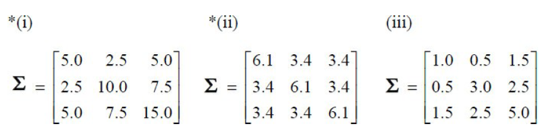

根據 Kirk 8.4，若共變異數矩陣的對角線元素相同，而非對角線元素也相同，則為S matrix。  
若滿足以下關係式，則為H matrix:

$$\sigma_{Y_j}^2+\sigma_{Y_j'}^2-2\sigma_{Y_jY_j'}=a \;constant\; for\; all \;j\;ana\;j'\;(j\neq j')$$

1. 不滿足對角線元素相同且非對角線元素相同，但
   $$\sigma_{Y_1}^2+\sigma_{Y_2}^2-2\sigma_{Y_1Y_2}=5+10-2.5\times2=10\\
   \sigma_{Y_2}^2+\sigma_{Y_3}^2-2\sigma_{Y_2Y_3}=10+15-7.5\times2=10\\
   \sigma_{Y_1}^2+\sigma_{Y_3}^2-2\sigma_{Y_1Y_3}=5+15-5\times2=10\\$$
   故為H matrix。
2. 對角線元素皆為6.1，且非對角線元素皆為3.4，故為 S matrix。
3. 不滿足對角線元素相同且非對角線元素相同，但
   $$\sigma_{Y_1}^2+\sigma_{Y_2}^2-2\sigma_{Y_1Y_2}=1+3-0.5\times2=3\\
   \sigma_{Y_2}^2+\sigma_{Y_3}^2-2\sigma_{Y_2Y_3}=3+5-2.5\times2=3\\
   \sigma_{Y_1}^2+\sigma_{Y_3}^2-2\sigma_{Y_1Y_3}=1+5-1.5\times2=3\\$$
   故為H matrix。

# 9.3 List the treatment combinations for the following factorial designs.

1. CRF22  
   若將第一個treatment以a表示，第二個treatment以b表示則，所有treatment的組合為:

$$treatment \;combinations=\{\;a_1b_1,a_1b_2,a_2b_1,a_2b_2\;\}$$

2. CRF23  
   若將第一個treatment以a表示，第二個treatment以b表示則，所有treatment的組合為:

$$treatment \;combinations=\{\;a_1b_1,a_1b_2,a_1b_3,a_2b_1,a_2b_2,a_2b_3\;\}$$

3. CRF33  
   若將第一個treatment以a表示，第二個treatment以b表示則，所有treatment的組合為:

$$treatment \;combinations=\{\;a_1b_1,a_1b_2,a_1b_3,a_2b_1,a_2b_2,a_2b_3,a_3b_1,a_3b_2,a_3b_3\;\}$$

# 9.15 When does $\sum\nolimits_{i=1}^{p-1}SSB\hat{\Psi_{i(A)}}=\sum\nolimits_{j=1}^{pq1}SSA\hat{\Psi_{j(B)}}=SSAB?$

當contrast彼此互為正交時，treatment contrast interaction 的總和與 treatment treatment interaction 相同。  
因此要滿足以上關係的話，treatment A 的所有contrast 互為正交，且 treatment B 的所有 contrast 也互為正交。

# 9.17 Assume that the expected values of the mean squares for a design are as follows:

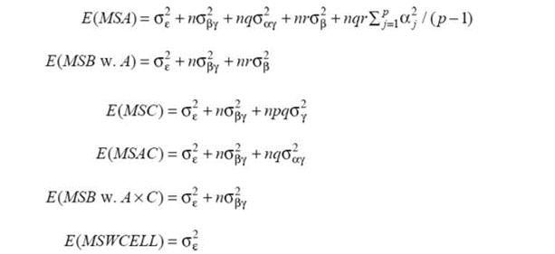

## Construct F′ and F″ statistics for testing treatment A.

根據課本p 405的公式，若要檢驗A 的組效果，則需要透過$E(MSA)、E(MSB w.A)、E(MSAC)、E(MSB w.A\times C)$來得到F’和F’‘，而F’和F’’分別為:

$$F'=\frac{E(MSA)}{E(MSB w.A)+E(MSAC)-E(MSB w.A\times C)}\\F''=\frac{E(MSA)+E(MSB w.A\times C)}{E(MSB w.A)+E(MSAC)}$$

# 9.19 Assume that the following data have been obtained for a CRF-322 design (model II) with $n_{jkl}$ equal to 2:

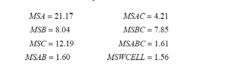

1. Perform preliminary tests on the model and pool where appropriate; write out the ANOVA table showing the values of mean squares and degrees of freedom.

```r
MSA=21.17
MSB=8.04
MSC=12.19
MSAB=1.6
MSAC=4.21
MSBC=7.85
MSABC=1.61
MSWCELL=1.56
F.abc=MSABC/MSWCELL
SSWCELL=MSWCELL*12
SSABC=MSABC*2
MSRES=(SSABC+SSWCELL)/14
SSAB=MSAB*2
F.ab=MSAB/MSRES
F.bc=MSBC/MSRES
F.ac=MSAC/MSRES
MSRES2=(SSAB+SSABC+SSWCELL)/16
```

$$MSRES=\frac{SSABC+SSWCELL}{(3-1)(2-1)(2-1)+3\times2\times2\times(2-1)}$$

接下來檢視是否存在二階交互作用。 虛無假設分別為:
$$H_0:\sigma^2_{\alpha\beta}=0\\
H_0:\sigma^2_{\alpha\gamma}=0\\
H_0:\sigma^2_{\beta\gamma}=0\\$$

檢定的F值為:

$$F_{\alpha\beta}=\frac{MSAB}{MSRES}\;\;F_{\alpha\gamma}=\frac{MSAC}{MSRES}\;\;F_{\beta\gamma}=\frac{MSBC}{MSRES}$$
$F_{\alpha\beta}$為1.0209663小於顯著值1.5330956($F_{0.25,2,14}$)，故保留虛無假設。而$F_{\alpha\gamma}$為2.6864175，大於顯著值1.5330956($F_{0.25,2,14}$)。$F_{\beta\gamma}$為5.0091158，大於顯著值1.4403367($F_{0.25,1,14}$)，故拒絕虛無假設。
存在AC和BC的交互作用，但不存在AB的交互作用。合並先前的$MSRES、MSAB$

$$MSRES=\frac{SSWCELL+SSABC+SSAB}{(3-1)(2-1)(2-1)+3\times2\times2\times(2-1)+(3-1)(2-1)}$$
MSRES變為1.57125，自由度為16。

則最後的ANOVA table為:

| Source | df | value |
| --- | --- | --- |
| MSA | 2 | 21.17000 |
| MSB | 1 | 8.04000 |
| MSC | 1 | 12.19000 |
| MSAC | 2 | 4.21000 |
| MSBC | 1 | 7.85000 |
| MSRES | 16 | 1.57125 |

2. Indicate the expected values of the mean squares for the final model.
   該模型的方程式為
   $$Y_{ijkl}=\mu+\alpha_j+\beta_{k}+\gamma_l+(\alpha\gamma)_{jl}+(\beta\gamma)_{kl}+\epsilon_{i(jkl)}\\
   i=1,2\;\;\;j=1,2,3\;\;\;k=1,2\;\;\;l=1,2\\
   \mu:grand\;mean\\
   \alpha_j:effect\;of\;treatment\;A\\
   \beta_{k}:effect\;of\;treatment\;B\\
   \gamma_l:effect\;of\;treatment\;C\\
   (\alpha\gamma)_{jl}:effect\;of\;A\;C\;interaction\\
   (\beta\gamma)_{kl}:effect\;of\;B\;C\;interaction\\
   \epsilon_{i(jkl)}:error\;term$$
   其中A、B、C全是random effect。根據課本9.10的方式，能夠得到以下表格:

   | Source | i | j | k | l | E(MS) |
   | --- | --- | --- | --- | --- | --- |
   | A | n | 1-p/P | q | r | $nqr\sigma_{\alpha}^2+nq\sigma_{\alpha\gamma}^2+\sigma_{\epsilon}^2$ |
   | B | n | p | 1-q/Q | r | $npr\sigma_{\beta}^2+np\sigma_{\beta\gamma}^2+\sigma_{\epsilon}^2$ |
   | C | n | p | q | 1-r/R | $npq\sigma_{\gamma}^2+nq\sigma_{\alpha\gamma}^2+np\sigma_{\beta\gamma}^2+\sigma_{\epsilon}^2$ |
   | AC | n | 1-p/P | 1-q/Q | 1-r/R | $nq\sigma_{\alpha\gamma}^2+\sigma_{\epsilon}^2$ |
   | BC | n | p | 1-q/Q | 1-r/R | $np\sigma_{\beta\gamma}^2+\sigma_{\epsilon}^2$ |
   | RES | 1-n/N | 1 | 1 | 1 | $\sigma_{\epsilon}^2$ |

   其中$n=2,p=3,q=2,r=2$。
3. Construct an F′ statistic for testing treatment C. 根據以上表格，C組效果的F’為
   $$F'=\frac{E(MSC)}{E(MSAC)+E(MSBC)-E(MSRES)}$$

F’的數值為1.1621976

# 10.10 Suppose that the following data have been obtained for an RBF-23 design. Assume that the treatments are fixed effects and the blocks are random effects.

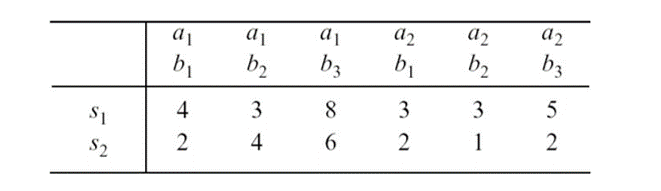

```r
treatment_A=rep(c(rep("a1",3),rep("a2",3)),2)
treatment_B=rep(rep(c("b1","b2","b3"),2),2)
measurement=c(4,3,8,3,3,5,2,4,6,2,1,2)
ID=as.factor(c(rep(1,6),rep(2,6)))
repdata=data.frame(measurement,ID,treatment_A,treatment_B)
Y=(sum(repdata$measurement))^2/(2*3*2)
ABS=sum(measurement^2)
S=(sum(repdata[ID=="1",]$measurement)^2+sum(repdata[ID=="2",]$measurement)^2)/(3*2)
A=sum(repdata[treatment_A=="a1",]$measurement)^2+sum(repdata[treatment_A=="a2",]$measurement)^2
A=A/(2*3)
B=sum(repdata[treatment_B=="b1",]$measurement)^2+sum(repdata[treatment_B=="b2",]$measurement)^2+sum(repdata[treatment_B=="b3",]$measurement)^2
B=B/(2*2)
N=repdata[ID=="1",]$measurement+repdata[ID=="2",]$measurement
AB=sum(N^2)/2
SSTO=ABS-Y
SSBL=S-Y
SSA=A-Y
SSB=B-Y
SSAB=AB-A-B+Y
SSRES=ABS-AB-S+Y
n=2
p=2
q=3
MSBL=SSBL/(n-1)
MSA=SSA/(p-1)
MSB=SSB/(q-1)
MSAB=SSAB/((p-1)*(q-1))
MSRES3=SSRES/((n-1)*(p*q-1))
F_A=MSA/MSRES3
F_B=MSB/MSRES3
F_AB=MSAB/MSRES3
F_BL=MSBL/MSRES3
s.Ybar=sqrt(MSRES3/4)
repdata <- repdata %>% group_by(treatment_B)
B.mean <- repdata %>% summarise(.,treat.mean=mean(measurement))
c1=c(1,-1,0)
c2=c(1,0,-1)
c3=c(0,1,-1)
FH12=sum(B.mean$treat.mean*c1)/s.Ybar
FH13=sum(B.mean$treat.mean*c2)/s.Ybar
FH23=sum(B.mean$treat.mean*c3)/s.Ybar
```

# 14.2 What is the principal advantage of a Latin square design over completely randomized and randomized block designs?

由於拉丁方格設計能夠排除兩個混淆變項(nuisance variable)，故相較於 completely randomized 和 randomized block designs在設計上更為有效。

# 14.3 Why is a Latin square design rarely used in behavioral and educational research?

由於拉丁方格設計假設不存在交互作用項，若存在交互作用項，則估計會存在偏誤。且該設計需要兩個nuisance variable的treatment level相同，在行為與教育研究上較為困難。

# 14.13 Suppose that the efficiency of a LS-4 design relative to that for a CR-4 design was found to be 1.35. Interpret this relative efficiency index.

該指標為1.35代表當實驗設計為CR-4而非LS-4時，所估計的 error variance 將膨脹為1.35倍。因此代表LS-4n我估計的 error variance 較小，較為有效。

# 11.7 Identify the following designs; assume in each case that the building block design is a CR-p design.

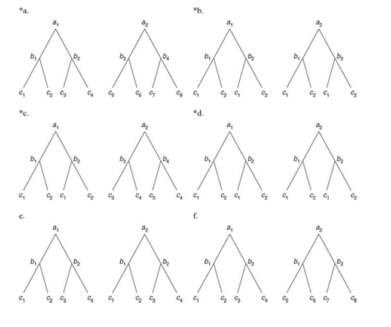

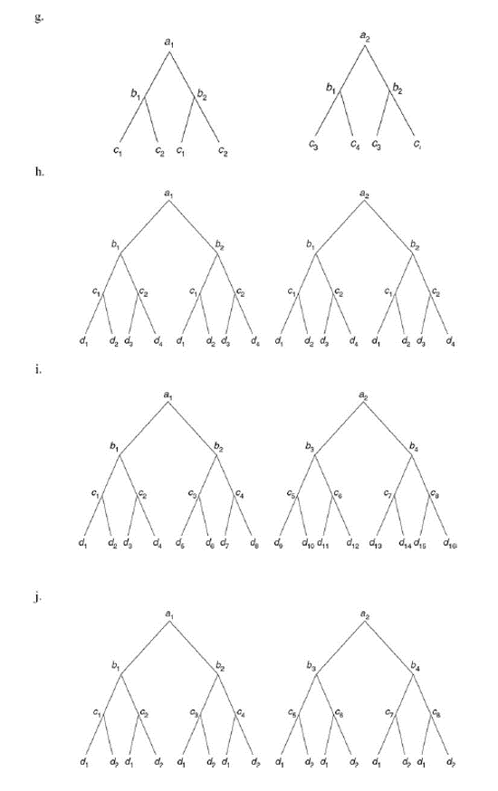

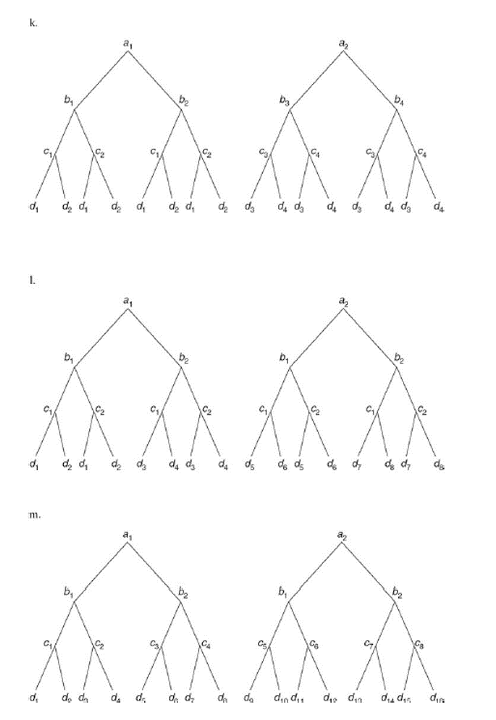

# 11.8 Explain why the following is not a hierarchical design.

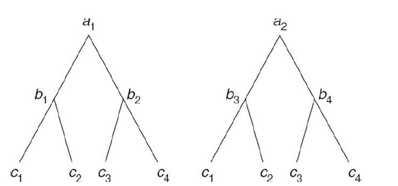

根據Kirk 的定義: In a hierarchical design, the levels of at least one treatment are nested in those of another treatment, and the remaining treatments are completely crossed.

而 nested的定義為:If each level of, say, treatment B appears with only one level of treatment A, B is said to be nested in A.

而在上圖的例子中 B 的組效果是巢套於A的組效果，而C的組效果和A的組效果為completely crossed 。但是C的組效果並不巢套於 B的組效果，例如 c1 就出現在 b1和 b3下，但是B和C也並非completely crossed。故不符合定義，不為階層性模型( hierarchical design)。